# Consumer Behavior & Delivery Analytics: A Swiggy Dataset Exploration

## 🏢 Swiggy Company Insights

Swiggy is one of India’s largest online food delivery platforms, known for its hyperlocal logistics network and customer-centric approach. Founded in 2014, it has expanded beyond food into groceries, alcohol delivery, and even concierge services through **Swiggy Genie**.

### 💼 Business Model

- **Marketplace Aggregator**: Connects restaurants with customers via a centralized app.
- **Revenue Streams**:
  - Delivery fees
  - Restaurant commissions
  - In-app advertising
  - Subscription model (**Swiggy One**)
- **Tech-Driven Logistics**:
  - Real-time traffic and weather data
  - Demand forecasting
  - Route optimization for faster deliveries

This business model supports Swiggy’s ability to deliver food efficiently while maintaining high customer satisfaction. The dataset used in this project reflects key operational metrics that align with Swiggy’s strategic goals — including delivery time, ratings, pricing, and cuisine preferences.

## 📊 Dataset Insights

This dataset provides a structured view of restaurant listings on Swiggy, capturing key attributes that influence customer experience and operational efficiency.

### 🧾 Column Descriptions

- **ID**: Unique identifier for each restaurant or entry
- **Area**: Locality or neighborhood where the restaurant is located
- **City**: Name of the city
- **Restaurant**: Name of the restaurant
- **Price**: Average price of an order (in ₹)
- **Avg_Ratings**: Average customer rating (e.g., 4.2 out of 5)
- **Total_Ratings**: Total number of ratings received
- **Food_Type**: Cuisine or category (e.g., Chinese, South Indian)
- **Address**: Full restaurant address
- **Delivery_Time (min)**: Estimated delivery time in minutes

These features enable exploratory data analysis (EDA), customer behavior modeling, and performance benchmarking across cities, cuisines, and delivery metrics.

# 🚀 Problem Statements – Swiggy Dataset Analysis

The objective is to analyze Swiggy’s restaurant dataset to uncover patterns, customer preferences, and operational trends for better decision-making.

### 🔹 Data Cleaning

1. Handle missing values in numeric & categorical columns.
2. Remove duplicates and fix data types.
3. Standardize inconsistent values (City, Food type).
4. Detect and treat outliers in Price, Ratings, Delivery time.

### 🔹 Exploratory Data Analysis (EDA)

5. **Average Delivery Time by City** – Compare delivery performance across cities.
6. **Distribution of Ratings by City (Boxplot)** – Identify variability, medians & outliers.
7. **Top 10 Restaurants by Count** – Find most frequently listed / ordered restaurants.
8. **Price Distribution (Histogram)** – Understand price range & spending trends.
9. **Highest-Rated Area in Each City** – Spot local hotspots with top customer satisfaction.
10. **Average Ratings per City** – Benchmark customer experience across cities.
11. **Top 3 Cuisines per City** – Reveal most popular food types region-wise.
12. **Unique Restaurants per City** – Measure restaurant variety available in each city.
13. **City-Level Summary (Price, Ratings, Delivery time)** – Compare overall performance.
14. **City & Area Aggregation (with cuisines & restaurants)** – View combined trends across numeric & non-numeric data.
15. **Correlation Heatmap** – Explore relationships between price, ratings, delivery time, etc.

### 🔹 Business Insights

16. Which cities deliver **fastest vs slowest**?
17. Which cities/areas have **highest vs lowest customer ratings**?
18. Which cuisines dominate in each region?
19. Do **higher prices correlate with better ratings**?
20. Does **delivery time impact ratings**?
21. Which areas/cities should Swiggy **target for promotions or growth**?
22. Which restaurants are **most popular** among customers?

```python
#core libraries

import numpy as np
import pandas as pd

#visualization libraries

import matplotlib.pyplot as plt
import seaborn as sns
```

```python
#load dataset

df= pd.read_csv(r"C:\Users\Vrishikaa\Downloads\archive (2)\swiggy.csv")
df.head(2)
```

|  | ID | Area | City | Restaurant | Price | Avg ratings | Total ratings | Food type | Address | Delivery time |
| --- | --- | --- | --- | --- | --- | --- | --- | --- | --- | --- |
| 0 | 211 | Koramangala | Bangalore | Tandoor Hut | 300.0 | 4.4 | 100 | Biryani,Chinese,North Indian,South Indian | 5Th Block | 59 |
| 1 | 221 | Koramangala | Bangalore | Tunday Kababi | 300.0 | 4.1 | 100 | Mughlai,Lucknowi | 5Th Block | 56 |

```python
# to remove duplicates

df.duplicated().sum()
df.drop_duplicates(inplace=True)
```

```python
#drop duplicates from the column

df = df.drop_duplicates()
```

```python
#to check if duplicates are droped or not

df.head(2)
```

|  | ID | Area | City | Restaurant | Price | Avg ratings | Total ratings | Food type | Address | Delivery time |
| --- | --- | --- | --- | --- | --- | --- | --- | --- | --- | --- |
| 0 | 211 | Koramangala | Bangalore | Tandoor Hut | 300.0 | 4.4 | 100 | Biryani,Chinese,North Indian,South Indian | 5Th Block | 59 |
| 1 | 221 | Koramangala | Bangalore | Tunday Kababi | 300.0 | 4.1 | 100 | Mughlai,Lucknowi | 5Th Block | 56 |

```python
#need to get the number of rows and columns

df.shape
```

```
(8680, 10)
```

```python
#information from the data-set

df.info()
```

```
<class 'pandas.core.frame.DataFrame'>
RangeIndex: 8680 entries, 0 to 8679
Data columns (total 10 columns):
 #   Column         Non-Null Count  Dtype
---  ------         --------------  -----
 0   ID             8680 non-null   int64
 1   Area           8680 non-null   object
 2   City           8680 non-null   object
 3   Restaurant     8680 non-null   object
 4   Price          8680 non-null   float64
 5   Avg ratings    8680 non-null   float64
 6   Total ratings  8680 non-null   int64
 7   Food type      8680 non-null   object
 8   Address        8680 non-null   object
 9   Delivery time  8680 non-null   int64
dtypes: float64(2), int64(3), object(5)
memory usage: 678.3+ KB
```

```python
#to get the idea of all columns by mathematical insights

df.describe()
```

|  | ID | Price | Avg ratings | Total ratings | Delivery time |
| --- | --- | --- | --- | --- | --- |
| count | 8680.000000 | 8680.000000 | 8680.000000 | 8680.000000 | 8680.000000 |
| mean | 244812.071429 | 348.444470 | 3.655104 | 156.634793 | 53.967051 |
| std | 158671.617188 | 230.940074 | 0.647629 | 391.448014 | 14.292335 |
| min | 211.000000 | 0.000000 | 2.000000 | 20.000000 | 20.000000 |
| 25% | 72664.000000 | 200.000000 | 2.900000 | 50.000000 | 44.000000 |
| 50% | 283442.000000 | 300.000000 | 3.900000 | 80.000000 | 53.000000 |
| 75% | 393425.250000 | 400.000000 | 4.200000 | 100.000000 | 64.000000 |
| max | 466928.000000 | 2500.000000 | 5.000000 | 10000.000000 | 109.000000 |

```python
#to find the missing values

df.isnull().sum()
```

```
ID               0
Area             0
City             0
Restaurant       0
Price            0
Avg ratings      0
Total ratings    0
Food type        0
Address          0
Delivery time    0
dtype: int64
```

```python
#drop column

df.drop('Address',axis=1,inplace=True)
```

```python
df.head(1)
```

|  | ID | Area | City | Restaurant | Price | Avg ratings | Total ratings | Food type | Delivery time |
| --- | --- | --- | --- | --- | --- | --- | --- | --- | --- |
| 0 | 211 | Koramangala | Bangalore | Tandoor Hut | 300.0 | 4.4 | 100 | Biryani,Chinese,North Indian,South Indian | 59 |

```python
df.set_index(['City'],inplace=True)
df
```

| City | ID | Area | Restaurant | Price | Avg ratings | Total ratings | Food type | Delivery time |
| --- | --- | --- | --- | --- | --- | --- | --- | --- |
| Bangalore | 211 | Koramangala | Tandoor Hut | 300.0 | 4.4 | 100 | Biryani,Chinese,North Indian,South Indian | 59 |
| Bangalore | 221 | Koramangala | Tunday Kababi | 300.0 | 4.1 | 100 | Mughlai,Lucknowi | 56 |
| Bangalore | 246 | Jogupalya | Kim Lee | 650.0 | 4.4 | 100 | Chinese | 50 |
| Bangalore | 248 | Indiranagar | New Punjabi Hotel | 250.0 | 3.9 | 500 | North Indian,Punjabi,Tandoor,Chinese | 57 |
| Bangalore | 249 | Indiranagar | Nh8 | 350.0 | 4.0 | 50 | Rajasthani,Gujarati,North Indian,Snacks,Desser... | 63 |
| ... | ... | ... | ... | ... | ... | ... | ... | ... |
| Ahmedabad | 464626 | Panjarapole Cross Road | Malt Pizza | 500.0 | 2.9 | 80 | Pizzas | 40 |
| Delhi | 465835 | Rohini | Jay Mata Ji Home Kitchen | 200.0 | 2.9 | 80 | South Indian | 28 |
| Delhi | 465872 | Rohini | Chinese Kitchen King | 150.0 | 2.9 | 80 | Chinese,Snacks,Tandoor | 58 |
| Delhi | 465990 | Rohini | Shree Ram Paratha Wala | 150.0 | 2.9 | 80 | North Indian,Indian,Snacks | 28 |
| Ahmedabad | 466488 | Navrangpura | Sassy Street | 250.0 | 2.9 | 80 | Chaat,Snacks,Chinese | 44 |

8680 rows × 8 columns

```python
print(df.columns.tolist())
```

```
['ID', 'Area', 'Restaurant', 'Price', 'Avg ratings', 'Total ratings', 'Food type', 'Delivery time']
```

```python
df
```

| City | ID | Area | Restaurant | Price | Avg ratings | Total ratings | Food type | Delivery time |
| --- | --- | --- | --- | --- | --- | --- | --- | --- |
| Bangalore | 211 | Koramangala | Tandoor Hut | 300.0 | 4.4 | 100 | Biryani,Chinese,North Indian,South Indian | 59 |
| Bangalore | 221 | Koramangala | Tunday Kababi | 300.0 | 4.1 | 100 | Mughlai,Lucknowi | 56 |
| Bangalore | 246 | Jogupalya | Kim Lee | 650.0 | 4.4 | 100 | Chinese | 50 |
| Bangalore | 248 | Indiranagar | New Punjabi Hotel | 250.0 | 3.9 | 500 | North Indian,Punjabi,Tandoor,Chinese | 57 |
| Bangalore | 249 | Indiranagar | Nh8 | 350.0 | 4.0 | 50 | Rajasthani,Gujarati,North Indian,Snacks,Desser... | 63 |
| ... | ... | ... | ... | ... | ... | ... | ... | ... |
| Ahmedabad | 464626 | Panjarapole Cross Road | Malt Pizza | 500.0 | 2.9 | 80 | Pizzas | 40 |
| Delhi | 465835 | Rohini | Jay Mata Ji Home Kitchen | 200.0 | 2.9 | 80 | South Indian | 28 |
| Delhi | 465872 | Rohini | Chinese Kitchen King | 150.0 | 2.9 | 80 | Chinese,Snacks,Tandoor | 58 |
| Delhi | 465990 | Rohini | Shree Ram Paratha Wala | 150.0 | 2.9 | 80 | North Indian,Indian,Snacks | 28 |
| Ahmedabad | 466488 | Navrangpura | Sassy Street | 250.0 | 2.9 | 80 | Chaat,Snacks,Chinese | 44 |

8680 rows × 8 columns

## 📌 Problem Statement

Swiggy’s dataset contains multiple **numeric features** such as price, ratings, total ratings, and delivery time.  
Before building any **predictive model** or drawing **business insights**, it is important to check if these features are **correlated** with each other.

For example:

- Do higher prices lead to higher or lower ratings?
- Is delivery time strongly related to customer satisfaction?
- Does the number of ratings correlate with the average rating?

A **correlation heatmap** helps us quickly identify such relationships.

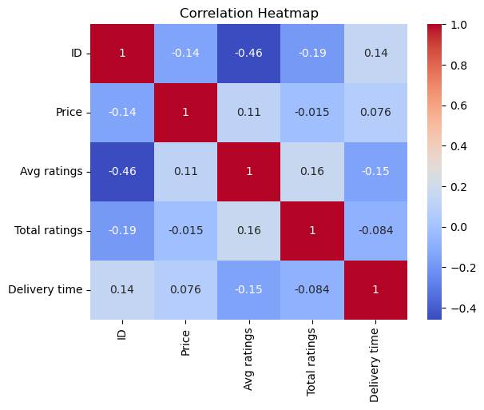

```python
# Create a correlation matrix of all numeric columns in the DataFrame
# numeric_only=True ensures only numbers are used (ignores text columns)

# Plot the heatmap using seaborn
# annot=True -> shows the correlation values inside each cell

# cmap='coolwarm' -> sets the color scheme (blue = negative, red = positive)

sns.heatmap(df.corr(numeric_only=True), annot=True, cmap='coolwarm')
plt.title("Correlation Heatmap")
plt.show()
```

## 📊 Business Insights

1. **Strong Positive Correlations**
   - If `Total Ratings` is positively correlated with `Avg Ratings`, it means **popular restaurants tend to have higher ratings**.
   - Business Action: Promote **well-rated, high-volume restaurants** more often on the homepage.
2. **Negative Correlations**
   - If `Delivery Time` is negatively correlated with `Avg Ratings`, longer delivery reduces satisfaction.
   - Business Action: Optimize **delivery logistics** in areas with slow times.
3. **Weak or No Correlation**
   - If `Price` shows little correlation with `Avg Ratings`, customers value **quality & delivery** more than just pricing.
   - Business Action: Focus less on discounts and more on **service reliability**.
4. **Cross-Metric Relationships**
   - Understanding how price, ratings, and delivery interact helps Swiggy create **balanced offers** (e.g., premium-priced but high-rated & fast restaurants for premium customers).

## 📌 Problem Statement

Food delivery platforms like **Swiggy** operate in multiple cities, and within each city, customer demand and restaurant performance vary by **area**. Decision-makers need to understand:

- Which **areas perform best** in terms of ratings and engagement.
- Which **cuisines and restaurants dominate** in each area.
- How **pricing and delivery times** differ across localities.

Without this area-level view, insights remain too broad (city-level only) and may not reveal pockets of high or low performance.

```python
#we need to form the group with city and with the view of all columns both numeric and non-numeric
City_df = df.groupby(['City', 'Area']).agg({
    'Price': 'mean',
    'Avg ratings': 'mean',
    'Total ratings': 'mean',
    'Delivery time': 'mean',
    'Restaurant': lambda x: ', '.join(map(str, x.unique()[:3])),  # ensure string
    'Food type': lambda x: ', '.join(map(str, x.unique()[:3]))
}).reset_index().round(2)

print(City_df.head())
```

```
        City                  Area   Price  Avg ratings  Total ratings  \
0  Ahmedabad   Akhbar Nagar Circle  200.00         2.90          80.00
1  Ahmedabad                 Acher  200.00         3.70         100.00
2  Ahmedabad             Ahmedabad  344.44         4.07         124.44
3  Ahmedabad              Ambavadi  200.00         4.40          20.00
4  Ahmedabad              Ambawadi  302.00         3.72          61.60

   Delivery time                                         Restaurant  \
0          53.00                              Shiv Shakti Fast Food
1          70.00                                Punjabi Food On Way
2          43.22  Prithvi Hotel, Fish Express, Grill N Rice Rest...
3          39.00                                        Mk Sandwich
4          38.56  Harshu'S Late Night Munchies, Umami By Curries...

                                           Food type
0                                 Gujarati,Fast Food
1                 North Indian,Chinese,Punjabi,Combo
2  Indian,Chinese,Continental, Indian,Tandoor,Sea...
3                         Chinese,American,Beverages
4  Fast Food,Italian,Chinese,Snacks, Indian,Chine...
```

```python
#to reset index asper the group of city

City_df = City_df.reset_index()
```

```python
City_df
```

|  | index | City | Area | Price | Avg ratings | Total ratings | Delivery time | Restaurant | Food type |
| --- | --- | --- | --- | --- | --- | --- | --- | --- | --- |
| 0 | 0 | Ahmedabad | Akhbar Nagar Circle | 200.00 | 2.90 | 80.00 | 53.00 | Shiv Shakti Fast Food | Gujarati,Fast Food |
| 1 | 1 | Ahmedabad | Acher | 200.00 | 3.70 | 100.00 | 70.00 | Punjabi Food On Way | North Indian,Chinese,Punjabi,Combo |
| 2 | 2 | Ahmedabad | Ahmedabad | 344.44 | 4.07 | 124.44 | 43.22 | Prithvi Hotel, Fish Express, Grill N Rice Rest... | Indian,Chinese,Continental, Indian,Tandoor,Sea... |
| 3 | 3 | Ahmedabad | Ambavadi | 200.00 | 4.40 | 20.00 | 39.00 | Mk Sandwich | Chinese,American,Beverages |
| 4 | 4 | Ahmedabad | Ambawadi | 302.00 | 3.72 | 61.60 | 38.56 | Harshu'S Late Night Munchies, Umami By Curries... | Fast Food,Italian,Chinese,Snacks, Indian,Chine... |
| ... | ... | ... | ... | ... | ... | ... | ... | ... | ... |
| 838 | 838 | Surat | Vesu | 333.33 | 3.70 | 67.14 | 56.29 | Kitchens Badshah, Paan Casa, Kurtosshhh | North Indian,Punjabi, Fast Food,Beverages, Fas... |
| 839 | 839 | Surat | Vip Road | 220.00 | 2.90 | 80.00 | 49.00 | Pizza Da Dhaba | Italian,Fast Food |
| 840 | 840 | Surat | Vishal Nagar | 228.33 | 3.93 | 56.67 | 57.00 | Famous Fast Food, Mr Pizza G, Only Dhosa | Fast Food, Pizzas,Fast Food, South Indian |
| 841 | 841 | Surat | Yamuna Nagar | 250.00 | 3.23 | 86.67 | 39.33 | Pizza World, Cross Road Restaurant, Malhar Dhosa | Italian-American,Fast Food, North Indian,Chine... |
| 842 | 842 | Surat | Yoginagar Society | 200.00 | 3.90 | 100.00 | 55.00 | Gopal Chinese | Chinese |

843 rows × 9 columns

```python
#to see the City_df to check the groupby fuction given

City_df
City_df.shape
```

```
(843, 9)
```

# 🏙️ Problem Statement: Identify Top-Performing Areas per City

In every city, customers may rate areas differently based on service quality, restaurant availability, and delivery experience.  
To help Swiggy focus on **local-level strategy**, we need to identify the **top-performing area in each city** (based on highest average rating).

```python
#to identify the top performing area per city
# Sort the dataset by 'City' first and then 'Avg ratings'
# - Sorting by 'City' keeps all areas of the same city together.
# - Sorting by 'Avg ratings' in descending order (False) ensures that
#   the top-rated areas appear first within each city.

City_df.sort_values(['City','Avg ratings'],ascending=[True,False])
```

|  | index | City | Area | Price | Avg ratings | Total ratings | Delivery time | Restaurant | Food type |
| --- | --- | --- | --- | --- | --- | --- | --- | --- | --- |
| 49 | 49 | Ahmedabad | Nava Naroda | 300.0 | 4.6 | 20.0 | 52.0 | Vadilal Ice Creams | Ice Cream |
| 3 | 3 | Ahmedabad | Ambavadi | 200.0 | 4.4 | 20.0 | 39.0 | Mk Sandwich | Chinese,American,Beverages |
| 9 | 9 | Ahmedabad | Chanakyapuri | 500.0 | 4.4 | 50.0 | 47.0 | Brick Kitchen - Five Petals | Indian,Chinese,Continental |
| 39 | 39 | Ahmedabad | Madhupura | 300.0 | 4.4 | 100.0 | 48.0 | New Mehfil Restaurant | North Indian,Continental |
| 55 | 55 | Ahmedabad | Odhav | 200.0 | 4.4 | 50.0 | 47.0 | Jay Shree Sanskar Ice Cream And Lassi Corner | Desserts,Beverages |
| ... | ... | ... | ... | ... | ... | ... | ... | ... | ... |
| 807 | 807 | Surat | Near Rto Pal Gam | 300.0 | 2.9 | 80.0 | 64.0 | Krazzy Chicken | Biryani,Indian |
| 819 | 819 | Surat | Puna Patia | 200.0 | 2.9 | 80.0 | 47.0 | Navjivan Hotel | North Indian |
| 822 | 822 | Surat | Safal Square Vesu | 200.0 | 2.9 | 80.0 | 60.0 | Indian Chicken Express | Fast Food,Indian |
| 824 | 824 | Surat | Sagrampuraathwa | 300.0 | 2.9 | 80.0 | 35.0 | Laziz Pizza | Pizzas,Fast Food,Pastas |
| 839 | 839 | Surat | Vip Road | 220.0 | 2.9 | 80.0 | 49.0 | Pizza Da Dhaba | Italian,Fast Food |

843 rows × 9 columns

```python
# 📌 Step 1: Sort the dataset by 'City' first and then 'Avg ratings'
# - Sorting by 'City' keeps all areas of the same city together.
# - Sorting by 'Avg ratings' in descending order (False) ensures that
#   the top-rated areas appear first within each city.

City_sorted = City_df.sort_values(['City','Avg ratings'],
                                  ascending=[True, False])

# Display the sorted table
City_sorted.head(10)
```

|  | index | City | Area | Price | Avg ratings | Total ratings | Delivery time | Restaurant | Food type |
| --- | --- | --- | --- | --- | --- | --- | --- | --- | --- |
| 49 | 49 | Ahmedabad | Nava Naroda | 300.0 | 4.6 | 20.0 | 52.0 | Vadilal Ice Creams | Ice Cream |
| 3 | 3 | Ahmedabad | Ambavadi | 200.0 | 4.4 | 20.0 | 39.0 | Mk Sandwich | Chinese,American,Beverages |
| 9 | 9 | Ahmedabad | Chanakyapuri | 500.0 | 4.4 | 50.0 | 47.0 | Brick Kitchen - Five Petals | Indian,Chinese,Continental |
| 39 | 39 | Ahmedabad | Madhupura | 300.0 | 4.4 | 100.0 | 48.0 | New Mehfil Restaurant | North Indian,Continental |
| 55 | 55 | Ahmedabad | Odhav | 200.0 | 4.4 | 50.0 | 47.0 | Jay Shree Sanskar Ice Cream And Lassi Corner | Desserts,Beverages |
| 22 | 22 | Ahmedabad | Hatkeshwar | 350.0 | 4.3 | 50.0 | 44.0 | Surbhi Restaurant | North Indian,Chinese |
| 27 | 27 | Ahmedabad | Jodhpur Tekra | 250.0 | 4.3 | 75.0 | 44.0 | Shakesee, 9834 The Fruit Truck | Beverages,Snacks,Fast Food,Desserts, Juices,Be... |
| 30 | 30 | Ahmedabad | Kalupur | 250.0 | 4.3 | 50.0 | 45.0 | Jalaram | North Indian |
| 18 | 18 | Ahmedabad | Girdhar Nagar | 550.0 | 4.2 | 100.0 | 46.0 | Rajkamal | Indian |
| 19 | 19 | Ahmedabad | Gomtipur | 250.0 | 4.2 | 50.0 | 43.0 | Kanpur Mithai House | Sweets,Desserts |

```python
# 📌 Step 2: Extract the *Top Performing Area* for each City
# - After sorting, the top row for each city will represent
#   the area with the highest average rating.
# - groupby('City').head(1) picks the first row per city group.

top_area_per_city = City_sorted.groupby('City').head(1).reset_index()

# Display results
top_area_per_city
```

|  | level_0 | index | City | Area | Price | Avg ratings | Total ratings | Delivery time | Restaurant | Food type |
| --- | --- | --- | --- | --- | --- | --- | --- | --- | --- | --- |
| 0 | 49 | 49 | Ahmedabad | Nava Naroda | 300.0 | 4.6 | 20.0 | 52.0 | Vadilal Ice Creams | Ice Cream |
| 1 | 155 | 155 | Bangalore | Viveka Nagar | 199.0 | 4.6 | 100.0 | 50.0 | Maven Kitchen | Naga,Chinese |
| 2 | 197 | 197 | Chennai | Mogapair | 300.0 | 4.7 | 20.0 | 86.0 | Keventers Ice Creamery | Ice Cream,Desserts |
| 3 | 314 | 314 | Delhi | Vardhman Premium Mall | 700.0 | 4.8 | 20.0 | 53.0 | Biryani By Kilo | Biryani,Mughlai,Kebabs,North Indian,Hyderabadi... |
| 4 | 378 | 378 | Hyderabad | Kalyan Nagar X Roads | 200.0 | 4.5 | 50.0 | 71.0 | Gelatica Gelato - Ice Cream & Sorbet The Finest | Ice Cream Desserts |
| 5 | 516 | 516 | Kolkata | Girish Park | 300.0 | 4.9 | 20.0 | 37.0 | Pabrai'S Fresh And Naturelle Icecream | Ice Cream,Beverages,Desserts |
| 6 | 646 | 646 | Mumbai | Matunga East | 400.0 | 4.7 | 20.0 | 53.0 | Myfroyoland | Desserts Ice Cream |
| 7 | 692 | 692 | Pune | Dhole Patil Road | 150.0 | 4.5 | 50.0 | 39.0 | Sweet Bengal | Sweets,Indian,Snacks,Desserts |
| 8 | 835 | 835 | Surat | Umra Jakat | 150.0 | 4.6 | 100.0 | 44.0 | Natural Ice Cream | Ice Cream |

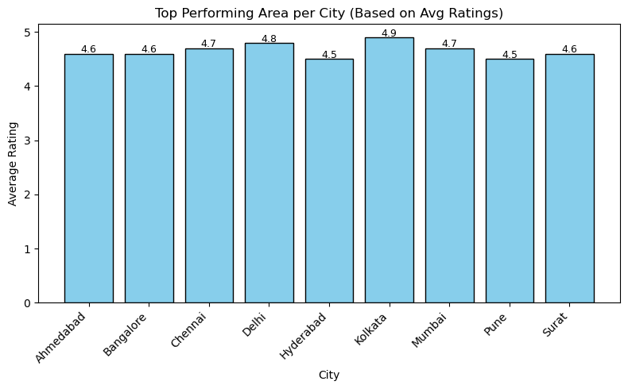

```python
# 📊 Step 3: Visualize the Top Performing Area per City

plt.figure(figsize=(8,5))

# Plot bar chart of top areas' average ratings

plt.bar(top_area_per_city['City'], top_area_per_city['Avg ratings'],
        color='skyblue', edgecolor='black')

# Add labels and title

plt.title("Top Performing Area per City (Based on Avg Ratings)")
plt.xlabel("City")
plt.ylabel("Average Rating")
plt.xticks(rotation=45, ha='right')

# Annotate bars with exact rating values

for i, val in enumerate(top_area_per_city['Avg ratings']):
    plt.text(i, val + 0.02, str(val), ha='center', fontsize=9)

plt.tight_layout()
plt.show()
```